# Exam 1 Solutions

Your name

2024-09-30

# Exam 1

```r
library(tidyverse)
```

### 1. (5 points) Load the data called dat.nsduh.small.csv. Take a look at the data.

```r
dat <- read_csv("dat.nsduh.small.csv")
```

Answer:

### 2. (5 points) Read the codebook. What do these variables represent: mjage, iralcage, sexatract, speakengl, and irsex?

Answer:

### 3. (5 points) What type of stat variables are the variables from #2?

```r
dat$mjage
```

```
##   [1] 14 11 12 16 14 12 13 20 33 18 13 16 21 12 14 18 18 16 18 20 15 16 15 12 16
##  [26] 19 10 16 17  9 16 16 15 18 13 20 18 16 18 15 14 15 16 17 16 27 22  9 15 18
##  [51] 14 16 20 18 17 15 15 16 18 14  7 17 18 21 19 13 15 18 13 18 11 17 17 15 21
##  [76] 20 14 30 21 13 22 20 16 25 15 15 15 18 14 12 12 35 11 16 21 17 13 21 12 14
## [101]  9 16 16 14 16 19 13 14 17 15 13 17 14 15 27 16 16 12 25 10 14 13 15 13 12
## [126] 13 16 17 13 18 11 14 14 18 11 14 14 15 15 15 14 17 17 16 17 17 32 14 17 14
## [151] 16 15 13 15 16 14 16 15 19 11 16 16 20 13  9 13 16 12 11 17 14
```

```r
dat$iralcage
```

```
##   [1] 14  5 12 18 14 18 13 21 16 19 13 16 19 12 17 16 18 12 15 10 15 16 18 14 14
##  [26] 17 14 18 23 11 11 19 12 16 10 18 18 15 18 20 13 12 20 17 15 18 13  9 17 16
##  [51] 18 16 16 17 10 14 19 14 18 15 14 12 18 18 21 14 14 16 12 16  5 15 15 14 15
##  [76] 16 16 18 13 14 21 13 16 21 13 15 15 18 12 12 13 13 11 17 16 16 14 18 12 21
## [101] 18 15 13 13 16 14 14 16 15 17 14 19 14 13 18 16 18 12 18 15 16 13 13 12 12
## [126] 13 12 15 21 17 11  8 14 14 13  8 13 15 16 15 16 12 19 15 16 16 18  7 16 13
## [151] 17 15 14 17 16 12 13 13 17 12 12 14 18 10 14 16 17 15 12 18 13
```

```r
dat$sexatract
```

```
##   [1]  1  2  2  1  4  4  1  1  1  1  1  1  1  1  1  1  1  1  1  1  5  1  1  5  2
##  [26]  1  1  1  1 99  1  1  1  2 99  1  1  1  1  2  1  1  1  1  2  1  1  3  1  1
##  [51]  2  1  1  1  1  1  1  1  1  1  1  3  2  1  1  3  1  1  1  1  1  1  1  1  1
##  [76]  1  1  5  1  1  1  1  1  4  1  1  2  1  1  1  1  2  2  1  1  1  6  1  1  1
## [101]  1  1  1  1  1  1  3  1  1  2  3  1  2  1  1  1  1  1  1  1  3  1  1  1  1
## [126]  1  2  3  1  1  3  1  1  1  1  1  1  1  1  1  1  1  1  1  1  1  1  1  1  1
## [151]  1  1  1  1  1  1  1  1  1  1  2  1  1  2  1  1  1  1  3  1 99
```

```r
dat$speakengl
```

```
##   [1] 1 1 1 1 1 1 1 1 1 1 1 1 1 1 1 1 1 1 1 1 1 1 1 1 1 1 1 2 1 1 1 1 1 1 1 3 1
##  [38] 1 1 1 1 1 1 1 1 1 1 1 1 1 1 1 1 1 1 1 1 1 1 1 1 1 1 1 1 1 1 1 1 1 1 3 1 1
##  [75] 1 1 1 1 1 1 1 1 1 1 1 1 1 1 1 1 1 1 1 1 1 1 1 1 1 1 1 1 1 2 1 1 1 1 1 1 2
## [112] 2 1 1 1 1 1 2 2 1 1 1 1 1 1 1 1 1 1 1 1 1 2 1 1 1 1 1 1 1 1 1 1 1 1 1 1 1
## [149] 1 1 1 1 1 1 1 1 1 1 1 1 1 1 2 1 1 1 1 1 1 1 1
```

```r
dat$irsex
```

```
##   [1] 1 2 2 1 1 2 1 1 2 2 1 1 1 2 2 2 1 2 1 1 1 2 1 2 2 2 1 1 2 1 1 1 1 2 1 2 2
##  [38] 2 2 1 2 1 1 1 2 1 1 2 2 1 2 1 1 2 2 1 1 1 2 1 1 2 2 1 2 2 1 2 1 1 1 2 2 2
##  [75] 2 2 1 1 1 2 1 2 1 2 2 1 1 2 2 1 1 2 2 2 1 1 1 2 2 1 2 2 2 1 1 2 2 1 2 2 2
## [112] 1 2 2 2 2 2 1 1 2 2 1 1 1 1 1 1 2 2 1 2 1 1 2 1 1 1 1 2 1 2 1 1 1 1 1 2 1
## [149] 1 2 1 2 1 1 1 1 2 1 2 1 2 2 1 2 1 1 1 1 2 2 2
```

Answer:

mjage: Quantitative

iralcage: Quantitative

sexatract: Categorical

speakengl: Categorical

irsex: Categorical

### 4. (5 points) Do visual EDA for mjage and iralcage, separately. (Hint: To compare the plots, make the axes limits, x and y, be the same for both plots. Also, try out different numbers of bins to see how they change.)

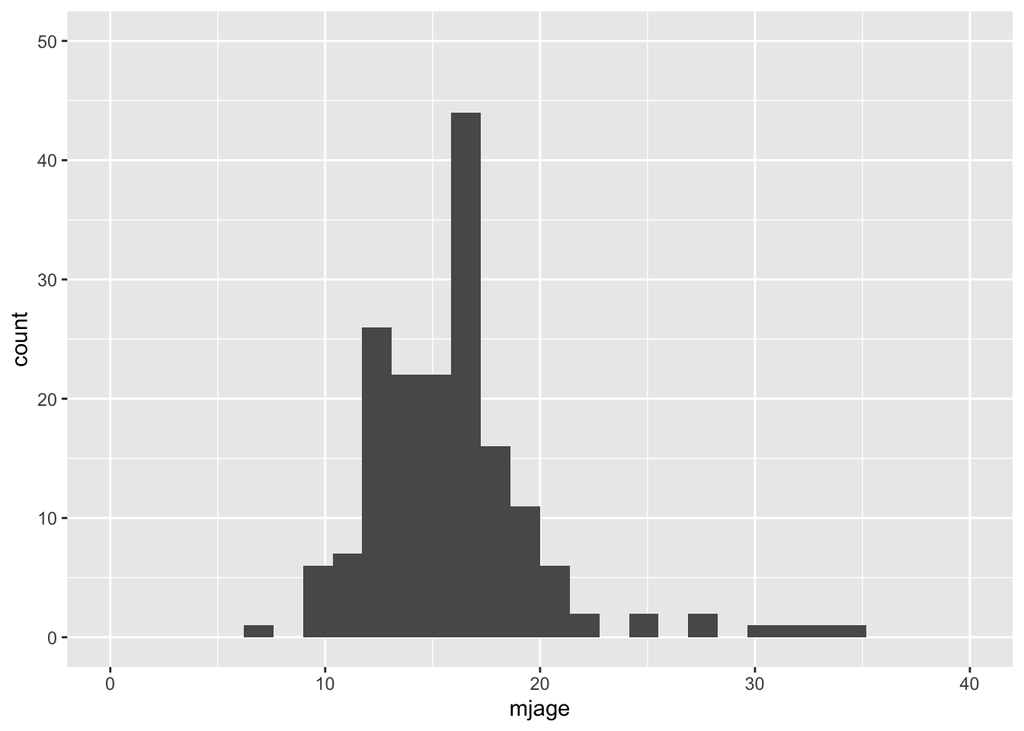

```r
#tidyverse version
dat %>% ggplot(aes(mjage)) + geom_histogram() + xlim(0,40) + ylim(0,50)
```

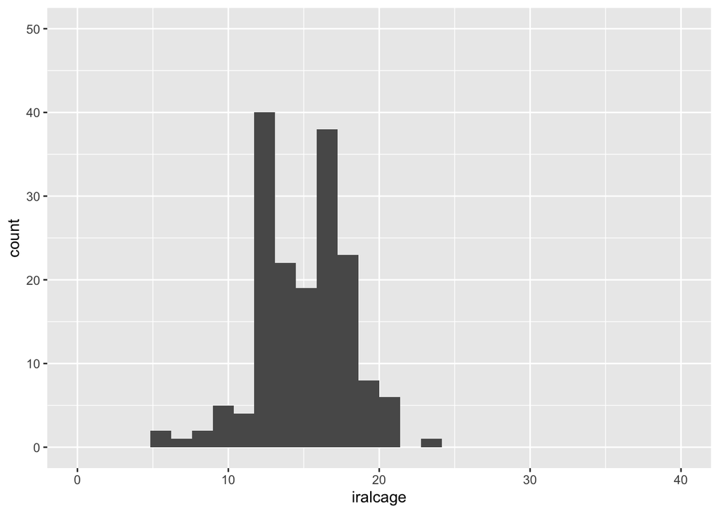

```r
dat %>% ggplot(aes(iralcage)) + geom_histogram() + xlim(0,40) + ylim(0,50)
```

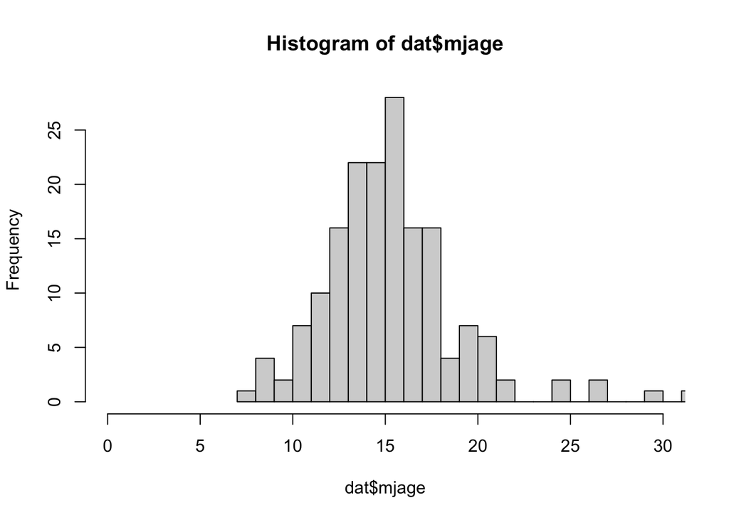

```r
# base R version
hist(dat$mjage, breaks = 20, xlim=c(0,30))
```

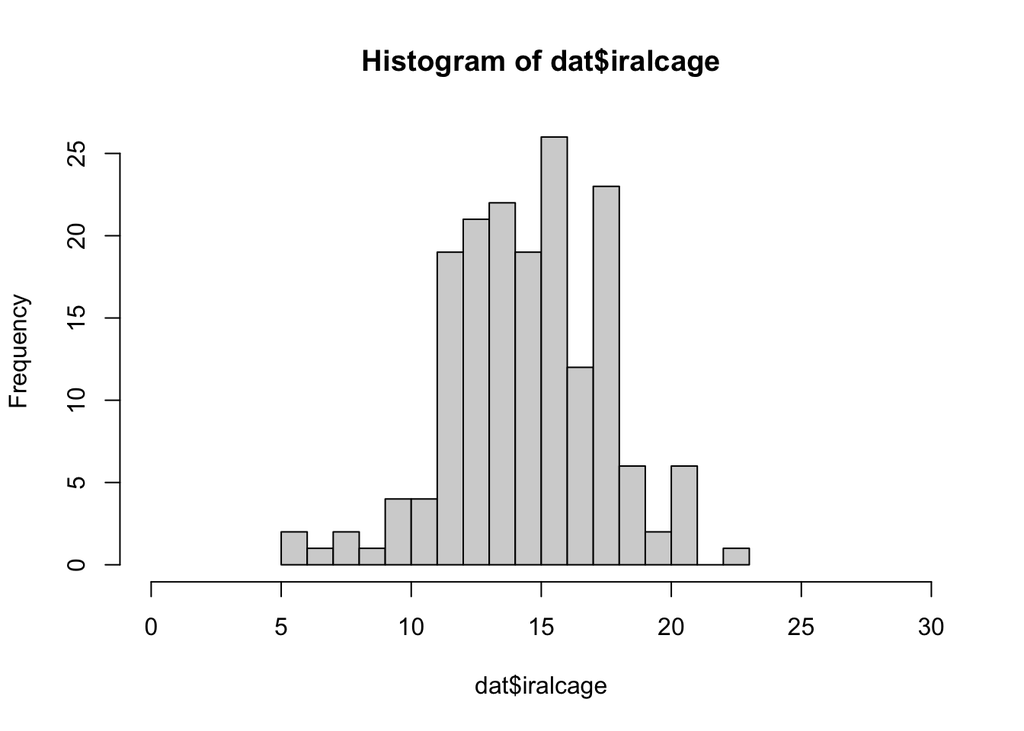

```r
hist(dat$iralcage, breaks = 20, xlim=c(0,30))
```

Answer:

mjage: Unimodal, symmetric, longer right tail, no clear outliers.

iralcage: Bimodal, symmetric, longer left tail, no clear outliers.

### 5. (5 points) Compare the two plots. How are they different and how are they similar? What theory do you have to explain these differences?

Answer: They’re similar, but iralcage is bimodal (perhaps some people try alcohol for the first time in high school and some try it in college) and has a longer left tail, meaning that people start using alcohol when they are younger, rather than older. For marijuana, there is a longer right tail, which means that some people start using when they are older.

### 6. (5 points) Do visual EDA for irsex and sexatract. What do you learn from this?

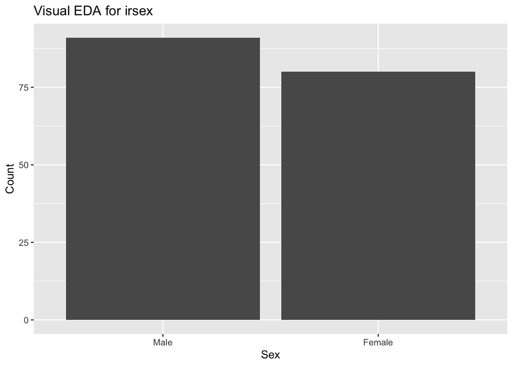

```r
# this code makes the levels of the factors take on the values from the codebook:
dat <- dat %>%
  mutate_at(c('irsex', 'sexatract', 'speakengl'), as.factor) %>%
  mutate(irsex = recode(irsex,         "1"="Male", "2"="Female"),
         sexatract = recode(sexatract, "1"="I am only attracted to opposite sex",
                                       "2"="I am mostly attracted to opposite sex",
                                       "3"="I am equally attracted to males and females",
                                       "4"="I am mostly attracted to same sex",
                                       "5"="I am only attracted to same sex",
                                       "6"="I am not sure",
                                       "99"="Legitimate skip"),
         speakengl = recode(speakengl, "1"="Very well",
                                       "2"="Well",
                                       "3"="Not well",
                                       "4"="Not at all"))

dat %>%
  ggplot(aes(irsex)) +
  geom_bar() +
  xlab("Sex") +
  ylab("Count") +
  ggtitle("Visual EDA for irsex")
```

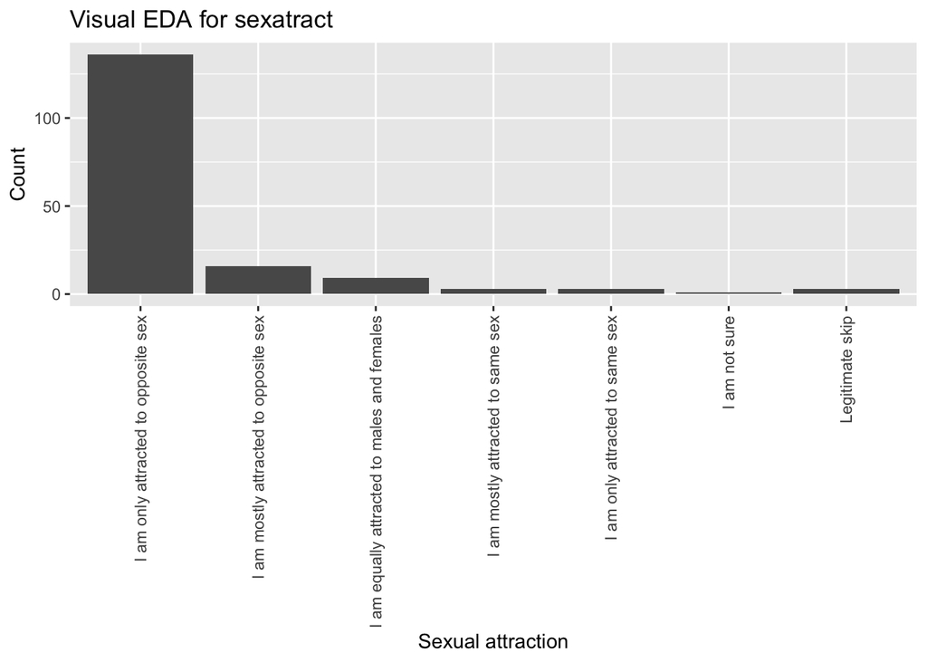

```r
dat %>%
  ggplot(aes(sexatract)) +
  geom_bar() +
  theme(axis.text.x = element_text(angle=90, vjust=.5, hjust=1)) +
  xlab("Sexual attraction") +
  ylab("Count") +
  ggtitle("Visual EDA for sexatract")
```

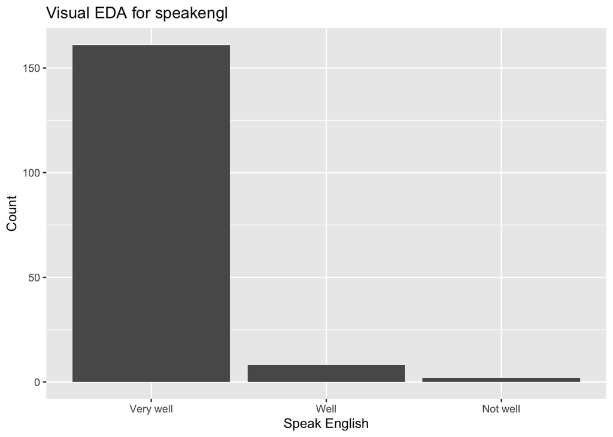

```r
dat %>% ggplot(aes(speakengl)) + geom_bar() + xlab("Speak English") + ylab("Count") + ggtitle("Visual EDA for speakengl")
```

Answer: There are more men than women in this sample, most people report only being attracted to the opposite sex, most people speak English very well.

### 7. (5 points) Do quantitative EDA for irsex, sexatract, and speakengl. What do you learn from this that you didn’t know from the visual EDA?

```r
dat %>%
  count(irsex)%>%
  mutate(prop = prop.table(n))
```

```
## # A tibble: 2 × 3
##   irsex      n  prop
##   <fct>  <int> <dbl>
## 1 Male      91 0.532
## 2 Female    80 0.468
```

```r
dat %>%
  count(sexatract)%>%
  mutate(prop = prop.table(n))
```

```
## # A tibble: 7 × 3
##   sexatract                                       n    prop
##   <fct>                                       <int>   <dbl>
## 1 I am only attracted to opposite sex           136 0.795
## 2 I am mostly attracted to opposite sex          16 0.0936
## 3 I am equally attracted to males and females     9 0.0526
## 4 I am mostly attracted to same sex               3 0.0175
## 5 I am only attracted to same sex                 3 0.0175
## 6 I am not sure                                   1 0.00585
## 7 Legitimate skip                                 3 0.0175
```

```r
dat %>%
  count(speakengl)%>%
  mutate(prop = prop.table(n))
```

```
## # A tibble: 3 × 3
##   speakengl     n   prop
##   <fct>     <int>  <dbl>
## 1 Very well   161 0.942
## 2 Well          8 0.0468
## 3 Not well      2 0.0117
```

Answer: The small numbers of the lower four categories.

### 8. (5 points) Copy your line from the visual EDA for mjage. What happens when you use this code “aes(x=mjage, fill=sexatract)” for the aesethetics in ggplot? Do you find out something interesting?

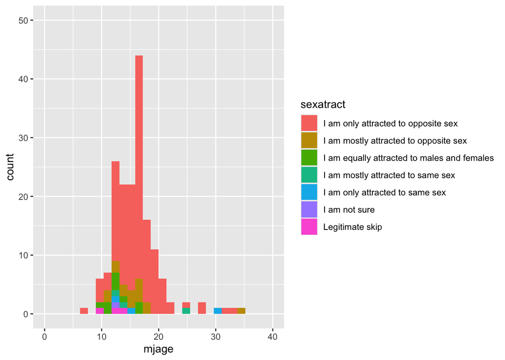

```r
dat %>% ggplot(aes(x=mjage, fill=sexatract)) + geom_histogram() + xlim(0,40) + ylim(0,50)
```

Answer: It looks like the individuals who are not just attracted to the opposite sex try marijuana at younger ages compared to those who are attracted only to the opposite sex.